# R Notebook

Testing the CTCRW model on a pig trajectory using the crawl package

## Simulating a CTCRW model using the framework described in Johnson et al. 2008, Ecology

The model is formulated as a state space Markov model.

Define the parameters and matrices of the model

```r
get_T = function(beta, delta){
  # Get the T matrix of the state space representation

  Tmat = matrix(c(1, (1 - exp(-beta*delta)) / beta,
                 0,   exp(-beta*delta)), nrow=2, ncol=2,
                byrow=TRUE)
  return(Tmat)
}
get_Q = function(beta, sigma, delta){
  # Get the Q matrix of the state-space formulation

    # beta : temporal auto-correlation parameter. Bigger beta, less directional persistence
  # delta : time step
  # sigma : variability in velocity

  # Velocity variance
  zeta_var = sigma^2*(1 - exp(-2*beta*delta)) / 2*beta

  # Location variance
  xi_var = (sigma^2 / beta^2)*(delta - (2/beta)*(1 - exp(-beta*delta)) +
                                 (1 / (2*beta))*(1 - exp(-2*beta*delta)))

  # Covariance between velocity and location
  vl_covar = (sigma^2 / (2*beta^2))*(1 - 2*exp(-beta*delta) +
                                    exp(-2*beta*delta))

  Q = matrix(c(xi_var, vl_covar, vl_covar, zeta_var), nrow=2, ncol=2,
             byrow = TRUE)
  return(Q)

}
```

Simulate the random walk

```r
# First two are location and velocity in one direction, second two are
# location and velocity in another direction. 2D vector
start_locvel = c(20, 0, 20, 0)
beta = 1 # Small beta implies more directional persistence
sigma_proc = 0.2 # Overal variability in velocity
sigma_obs = 0
delta = 0.2 # Time step
steps = 10000
true_locs = array(NA, dim=c(4, steps + 1))
true_locs[, 1] = start_locvel
obs_locs = array(NA, dim=c(2, steps + 1))
# These are for one dimension
Tmat = get_T(beta, delta)
Qmat = get_Q(beta, sigma_proc, delta) # location and velocity vcov
eta_mean = rep(0, 4) # location and velocity process error
# Observation matrix
zeromat = matrix(0, nrow=2, ncol=2)
Zvect = array(c(1, 0), dim=c(2, 1))
# Build the 4 dimensional vectors and matrices...why?  Because we are moving independently in two dimenions with location
# and velocity.
Tfull = rbind(cbind(Tmat, zeromat), cbind(zeromat, Tmat))
Qfull = rbind(cbind(Qmat, zeromat), cbind(zeromat, Qmat))
Zfull = rbind(c(Zvect, 0, 0), c(0, 0, Zvect))
for(i in 2:(steps + 1)){

  # State space formulation
  alpha_next = Tfull %*% true_locs[, i - 1] + MASS::mvrnorm(1, eta_mean, Qfull)
  true_locs[, i] = alpha_next
  obs_locs[, i] = Zfull %*% alpha_next + t(t(MASS::mvrnorm(1, c(0, 0), diag(rep(sigma_obs^2, 2)))))
}
```

```r
# Plot locations
locs = true_locs[c(1, 3), ]
plot(locs[1, ], locs[2, ])
lines(locs[1, ], locs[2, ])
```

[figure not shown]

```r
points(obs_locs[1, ], obs_locs[2, ], col="red")
```

```r
# Format the data for fitting with crawl
sim_dat = data.frame(t(obs_locs[, 2:ncol(obs_locs)]))
sim_dat$time = 1:(steps) * 0.2
colnames(sim_dat) = c("x", "y", "time")
sim_dat$ID = "sucks"
sim_dat
```

[output not shown]

[output cut: 90 more lines]

```r
library(crawl)
# a is the initial value for the location vector
# P is the initial correlation matrix
initial = list(a=c(20, 0, 20, 0),
               P=diag(c(1000^2,5400^2,1000^2,5400^2)))
constr = list(lower=c(-3, -3, -3), upper=c(4, 4, 4))
fit_sim = crwMLE(mov.mod=~1,
                  err.model=list(x=~1),
                  data=sim_dat,
                  Time.name="time",
                  coord=c('x', 'y'),
                  initial.state = initial,
                  constr=constr,
                  drift=FALSE,
                  fixPar=rep(NA, 3),
                  initialSANN=list(maxit=200, trace=1, REPORT=1))
```

```
Beginning SANN initialization ...
```

```
sann objective function values
sann stopped after 199 iterations
```

```
Beginning likelihood optimization ...
bounds can only be used with method L-BFGS-B (or Brent)
```

```r
fit_sim
```

```
Continuous-Time Correlated Random Walk fit

Models:
--------
Movement   ~ 1
Error   ~1

                     Parameter Est. St. Err. 95% Lower 95% Upper
ln tau (Intercept)           -2.870    0.241    -3.343    -2.396
ln sigma (Intercept)          0.946    0.197      0.56     1.333
ln beta (Intercept)           0.421    0.259    -0.086     0.929


Log Likelihood = 127.812
AIC = -249.623
```

```r
predTime <- seq(min(sim_dat$time), max(sim_dat$time), by=1000)
predObj <- crwPredict(object.crwFit=fit_sim, predTime,  flat=TRUE)
head(predObj)
```

|  | time | locType | x | y | ID | mu.x | nu.x | mu.y | nu.y | se.mu.x | se.nu.x | se.mu.y | se.nu.y | speed | predObs.x | predObs.y | outlier.chisq | naive.p.val |
| --- | --- | --- | --- | --- | --- | --- | --- | --- | --- | --- | --- | --- | --- | --- | --- | --- | --- | --- |
| 1 | 0.2 | p | 20.10408 | 20.17289 | sucks | 20.11382 | 2.9869060 | 20.16654 | 1.9641428 | 0.05606336 | 1.1410883 | 0.05606336 | 1.1410883 | 3.5748377 | 20.52372 | 19.89936 | 1.8086043 | 0.4048243 |
| 3 | 0.4 | o | 20.59611 | 20.53577 | sucks | 20.56628 | 1.2622593 | 20.54587 | 2.0607928 | 0.05822972 | 0.7385664 | 0.05822972 | 0.7385664 | 2.4166435 | 20.40945 | 20.59898 | 1.9293489 | 0.3811072 |
| 4 | 0.6 | o | 20.65591 | 21.00867 | sucks | 20.69314 | 0.6573028 | 21.02027 | 2.6000072 | 0.05036070 | 0.7250405 | 0.05036070 | 0.7250405 | 2.6818062 | 20.83165 | 21.06347 | 2.2306934 | 0.3278016 |
| 5 | 0.8 | o | 20.87924 | 21.50942 | sucks | 20.85244 | 0.4020308 | 21.47929 | 1.5355132 | 0.05035971 | 0.7248214 | 0.05035971 | 0.7248214 | 1.5872711 | 20.75272 | 21.36719 | 2.3856688 | 0.3033602 |
| 6 | 1.0 | o | 20.79247 | 21.62794 | sucks | 20.80871 | -0.5339571 | 21.64015 | 0.5563297 | 0.05035871 | 0.7248007 | 0.05035871 | 0.7248007 | 0.7711115 | 20.86912 | 21.68558 | 0.6057409 | 0.7386948 |
| 7 | 1.2 | o | 20.68374 | 21.78475 | sucks | 20.65556 | -1.2185662 | 21.81639 | 1.3010203 | 0.05035871 | 0.7248006 | 0.05035871 | 0.7248006 | 1.7825704 | 20.55075 | 21.93408 | 2.6329439 | 0.2680794 |

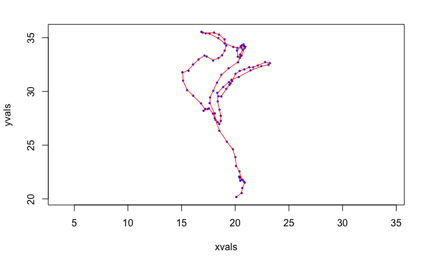

```r
crwPredictPlot(predObj, "map", asp=TRUE)
```

```r
##Create simulation object with 100 parameter draws
set.seed(123)
simObj <- crwSimulator(fit_sim, predTime, method="IS", parIS=100, scale=18/20)
```

```
Computing importance weights ...
```

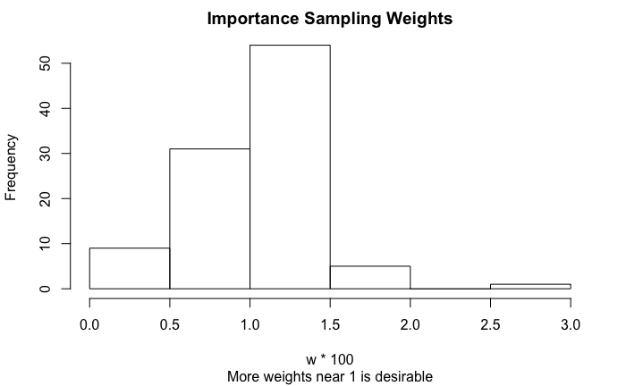

```r
# Look at the importance weights
w <- simObj$thetaSampList[[1]][,1]
hist(w*100, main='Importance Sampling Weights', sub='More weights near 1 is desirable')
```

```r
##Approximate number of independent samples
round(100/(1+(sd(w)/mean(w))^2))
```

```
[1] 89
```

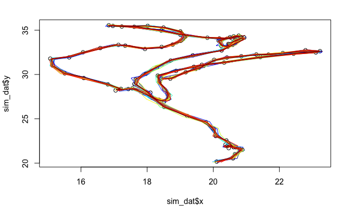

```r
## Sample 20 tracks from posterior predictive distribution
iter <- 20
cols <- jet.colors(iter)
plot(sim_dat$x, sim_dat$y)
for(i in 1:iter){

  samp <- crwPostIS(simObj, fullPost = TRUE)

  lines(samp$alpha.sim[,'mu.x'], samp$alpha.sim[,'mu.y'],col=cols[i], type="l")

}
```

Try fitting the model with STAN. Assume perfect data and no observation error.

```r
library(rstan)
tl = t(true_locs)
deltas = rep(1, nrow(tl) - 1)

standata = list(N=nrow(tl),
                obs_vals=tl,
                deltas=deltas)
saveRDS(standata, "temp_stan.rds")
stanfit = stan("stan_files/ctcrw_nobserr.stan", chains=3, data=standata, warmup=1000, iter=2000, cores=3)
```

```r
library(rethinking)
precis(stanfit)
```

[output not shown]

```r
just_loc = t(true_locs[c(1, 3), ])
standata2 = list(N = nrow(just_loc),
                 obs_vals=just_loc,
                 deltas=rep(1, nrow(just_loc) - 1))

fitstan2 = stan("stan_files/ctcrw_unobsvel.stan", data=standata2, warmup = 3000, iter=10000, cores=3, chains=3)
```

```r
precis(fitstan2)
traceplot(fitstan2, "beta")
```

[output not shown]

Ok, let’s scale this up to the last challenge (which is just not going to work well if the previous version struggled.). We have imperfect locations and unobserved velocities.

```r
sobs = t(obs_locs)
sobs[1, ] = c(20, 20)
standata3 = list(N=nrow(sobs),
                 obs_vals = sobs,
                 deltas = rep(1, nrow(sobs) - 1))
fitstan3 = stan("stan_files/ctcrw.stan", data=standata3, chains=3, cores=3, warmup=2000, iter=5000)
```

```r
precis(fitstan3)
```

[output not shown]

```r
predTime = seq(1, 21, len=100)

library(crawl)
predObj <- crawl::crwPredict(object.crwFit=fit_sim,
                      predTime,
                      speedEst=TRUE,
                      flat=TRUE)
```

Now, view the predicted movement path

```r
crwPredictPlot(predObj, "map")
```

[output not shown]

## Empirical data analysis

**Goal**: Fit the crawl model to some actual pig data. Figure out how pigs move differently during the day.

**0. Load in the data**

```r
library(data.table)
dat = fread("../data/formatted/pig_trajectories.csv")
dat$datetime = as.POSIXct(strptime(dat$datetime, format="%Y-%m-%d %H:%M:%S", tz="GMT"))
```

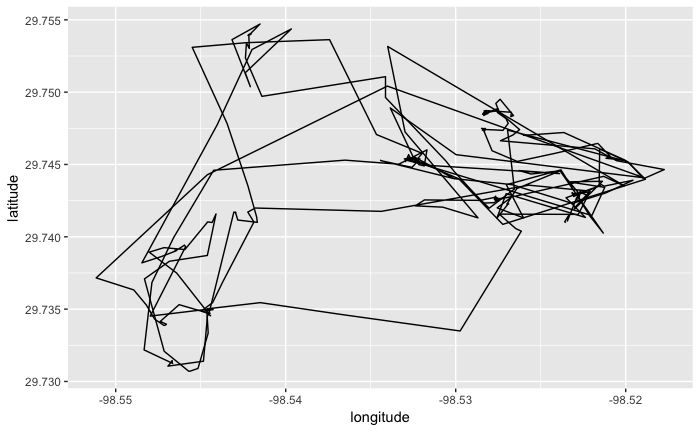

```r
library(ggplot2)
# Extract a single pigs trajectory
pig1 = dat[pigID == "20125txcamp"][1:400]
ggplot(data=pig1) + geom_path(aes(x=longitude, y=latitude))
```

Look at distance a pig traveled

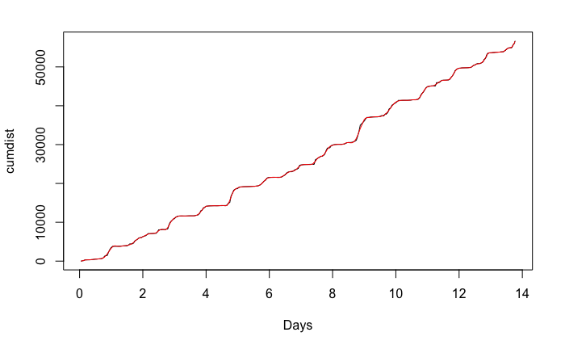

```r
library(geosphere)
get_distance_vect = function(longlat){
  # Calculate tghe distance that a pig traveled

  longs = longlat$longitude
  lats = longlat$latitude

  # Match distance vectors
  v1 = cbind(longs[-length(longs)], lats[-length(lats)])
  v2 = cbind(longs[-1], lats[-1])

  tuples = lapply(1:nrow(v1), function(i) list(v1[i, ], v2[i, ]))
  distvect = lapply(tuples, function(x) distm(x=x[[1]], y=x[[2]], fun=distHaversine))
  #
  return(distvect)
}
pigdists = get_distance_vect(pig1[, c("longitude", "latitude")])
pigtimes = diff(pig1$datetime)
days = cumsum(as.numeric(pigtimes)) / (60 * 24)
cumdist = cumsum(pigdists)
plot(days, cumdist, type="l", xlab="Days")
spl = smooth.spline(days, cumdist)
pred = predict(spl)
lines(days, pred$y, col="red")
```

```r
obsdiff = diff(cumdist) / diff(days)
plot(obsdiff, type="l")
predD = predict(spl, deriv=1)$y
lines(predict(spl, deriv=1)$y, type="l", col="red")
```

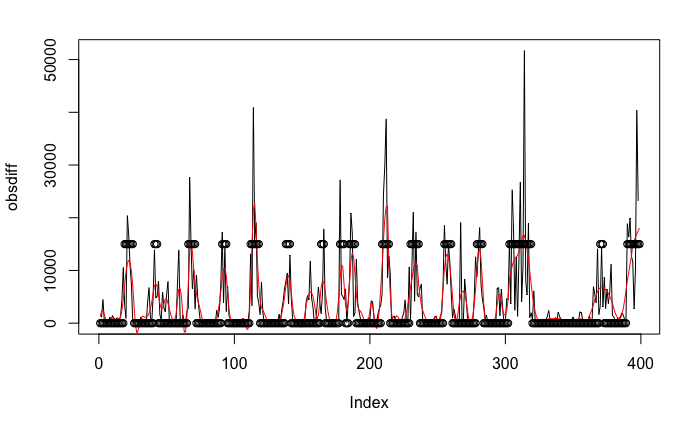

```r
fitk = kmeans(predD,centers = 2, nstart=200)
clusts = fitk$cluster
clusts[clusts == 1] = 15000
clusts[clusts == 2] = 0
points(clusts)
```

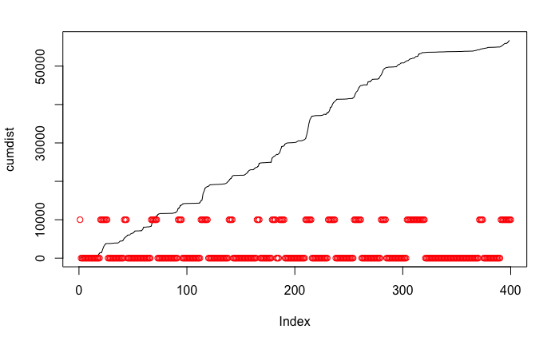

```r
calc_activity = function(time, cumdist, cluster=TRUE, nstart=20){
  # Calculate the activity covariate that determine whether or not an animal is resting
  #
  # 0: unhindered movement, 1: stopped

  # Fit spline to the cumulative movement function
  spl = smooth.spline(time, cumdist)
  pred_deriv = predict(spl, deriv=1)$y # predict the derivative
  #pred_deriv[pred_deriv < 0] = 0 # The cumulative distance plot can't have <0 derivative

  if(cluster){
    # Use clusterinng algorithm to differentiate stationary and moving time periods
    fitk = kmeans(pred_deriv, centers=2, nstart=20)

    # Identify the resting cluster
    resting = which.min(fitk$centers) == fitk$cluster

    # Convert the these resting points to a 0 to 1 scale
    restingActivity = 1 - pnorm(scale(pred_deriv[resting]))

    activity = rep(0, length(pred_deriv))
    activity[resting] = restingActivity

  } else{
    activity = 1 - pnorm(scale(pred_deriv))
  }


  return(c(0, activity))
}
activity = calc_activity(days, cumdist, cluster=T)
pig1$activity = activity
plot(cumdist, type="l")
act = activity
act[act == 0] = 10000
points(act, col="red")
```

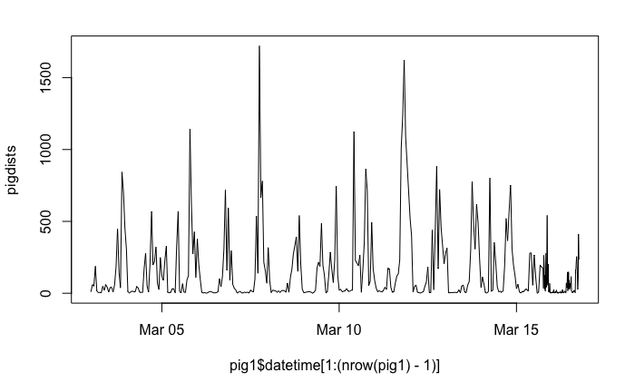

```r
plot(pig1$datetime[1:(nrow(pig1) - 1)], pigdists, type="l")
```

2. Project lat and long to the appropriate NAD measure

```r
library(sp)
library(rgdal)
coordinates(pig1) <- ~longitude+latitude
```

[output not shown]

Plot the projection to see what the data actuall look like

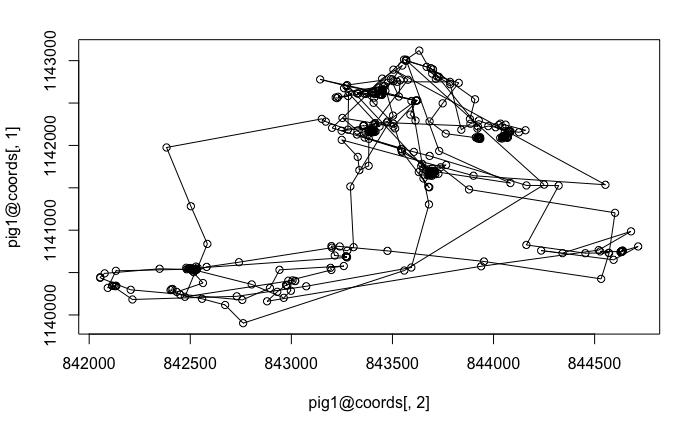

```r
plot(pig1@coords[, 2], pig1@coords[, 1])
lines(pig1@coords[, 2], pig1@coords[, 1])
```

```r
#print(nrow(short_dat))
```

3. Set the initial conditions

```r
library(crawl)
# Set the initial conditions for the location and movement vector. Location is at the starting location. Velocities start
# at 0.  P is the initial correlation matrix
initial = list(a=c(coordinates(pig1)[1,1],0,
                   coordinates(pig1)[1,2],0),
               P=diag(c(10000^2,5400^2,10000^2,5400^2)))
# Prior
# ln.prior = function(theta){-abs(theta[4]-3)/0.5}
```

```r
fixPar = c(0.01, 0.01, NA, NA, 0)
displayPar(mov.model=~1,
           err.model=list(x=~1, y=~1),
           activity=~activity,
           fixPar = fixPar,
           data=pig1)
```

| ParNames | fixPar | thetaIdx |
| --- | --- | --- |
| ln tau.x (Intercept) | 0.01 | NA |
| ln tau.y (Intercept) | 0.01 | NA |
| ln sigma (Intercept) | NA | 1 |
| ln beta (Intercept) | NA | 2 |
| ln phi | 0.00 | NA |

```r
# Make sure they are ordered
pig1 = pig1[order(pig1$datetime),]
```

```r
set.seed(123)
constr = list(lower=c(-10, -10), upper=c(10, 10))
fit1 <- crwMLE(mov.model=~1,
               err.model=list(x=~1, y=~1),
               activity=~activity,
               data=pig1,
               Time.name="datetime",
               initial.state=initial,
               constr=constr,
               fixPar = fixPar,
               theta=c(2, 2),
               method="L-BFGS-B",
               control=list(maxit=2000, trace=0,REPORT=1),
               initialSANN=list(maxit=2500, temp=10, trace=1, REPORT=10))
```

```
Beginning SANN initialization ...
```

```
sann objective function values
sann stopped after 2499 iterations
```

```
Beginning likelihood optimization ...
```

```r
fit1
```

```
Continuous-Time Correlated Random Walk fit

Models:
--------
Movement   ~ 1
Error   ~1 ~1

                     Parameter Est. St. Err. 95% Lower 95% Upper
ln tau.x (Intercept)          0.010        .         .         .
ln tau.y (Intercept)          0.010        .         .         .
ln sigma (Intercept)          3.008    0.029     2.952     3.064
ln beta (Intercept)           3.843     0.23     3.392     4.294
ln phi                        0.000        .         .         .


Log Likelihood = -19766201.812
AIC = 39532407.624
```

```r
predTime = seq(min(pig1$datetime), max(pig1$datetime), by="60 mins")
predObj <- crawl::crwPredict(object.crwFit=fit1,
                      predTime,
                      speedEst=TRUE,
                      flat=TRUE)
```

Now, view the predicted movement path

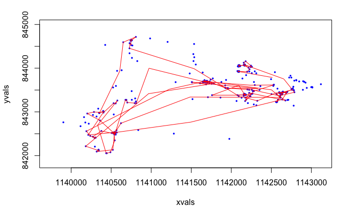

```r
crwPredictPlot(predObj, "map")
```

```r
simobj = crwSimulator(fit1, predTime, method="IS", parIS=100, scale=18/20)
```

```
Computing importance weights ...
```

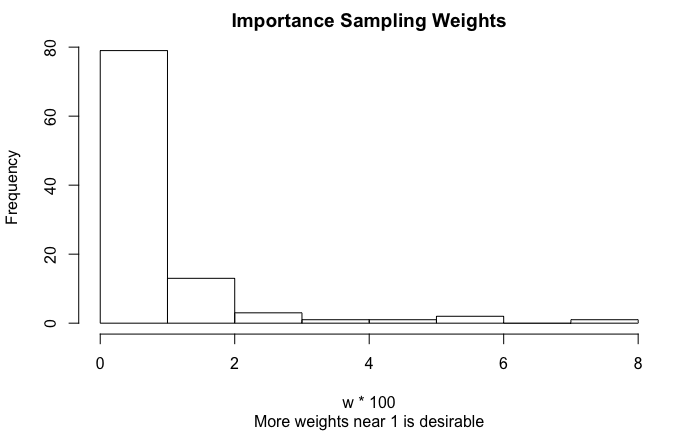

```r
# Look at the importance weights
w <- simobj$thetaSampList[[1]][,1]
hist(w*100, main='Importance Sampling Weights', sub='More weights near 1 is desirable')
```

```r
##Approximate number of independent samples
round(100/(1+(sd(w)/mean(w))^2))
```

```
[1] 47
```

```r
plot(pig1@coords[, 1], pig1@coords[, 2], cex=1, col="black", pch=18)
lines(pig1@coords[, 1], pig1@coords[, 2], cex=1, col="black")
```

```r
for(i in 1:3){
  samp = crwPostIS(simobj, fullPost=F)
  lines(samp$alpha.sim[, 'mu.x'], samp$alpha.sim[, 'mu.y'], col=colors()[i + 100])
}
points(pig1@coords[, 1], pig1@coords[, 2], cex=1, col="black", pch=18)
```

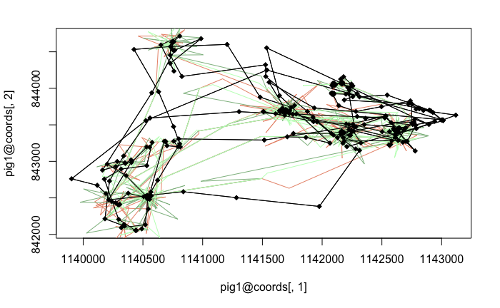

```r
lines(pig1@coords[, 1], pig1@coords[, 2], cex=1, col="black")
```

Hey…this worked this time